# Generate Tract to County/PR Crosswalk

Author

JP Walsh

Published

October 29, 2024

*Program for the creation of the 2020 Tract to 2022 County and Planning Regions crosswalk for UMF predictors*

Program: Written by JP Walsh 2024.

This program combines the overall tract to county crosswalk with the tract to planning region file to bring in Connecticut Planning Regions for the 2025 metric update.

Primary data derived from the University of Missouri’s [geographic correspondence engine](https://mcdc.missouri.edu/applications/geocorr.html).

Based on processes developed by Paul Johnson and Kevin Werner in SAS.

## Housekeeping

Read in packages for use.

```r
library(tidyverse)
library(Hmisc)
library(ipumsr)
library(reactable)

options(scipen = 999)
```

## Read data

Read the Tract to County crosswalks from the data file in the geographic-crosswalks folder. This is the format many of the metric programs are built around so we will copy the format to avoid issues.

The GeoCorr website allows for a variety of selections in creating your crosswalk file. The selections used to create the files read here are detailed below:

[Geocorr2022](https://mcdc.missouri.edu/applications/geocorr2022.html) Tract to County *States:* All *Source geography:* 2020 Tract *Target geography:* 2020 County *Weighting variable:* Population (2020 census) *Output Options:* Format CSV & Generate second allocation factor Tract to Planning Regions *States:* Connecticut *Source geography:* 2020 Tract *Target geography:* Connecticut Planning Region *Weighting variable:* Population (2020 census) *Output Options:* Format CSV & Generate second allocation factor

Read in the crosswalk file from the data folder inside the geographic-crosswalk folder.

```r
tract_county_2020 <- read_csv(here::here("geographic-crosswalks", "data", "tract-county-crosswalk_2020.csv"))
```

Replace counties from the state of Connecticut with Planning Regions for the 2020 crosswalk.

```r
ct_planning_regions <- read_csv(here::here("geographic-crosswalks", "data", "raw", "geocorr2022_tract_to_planning_regions_2022.csv")) %>%
  rename_with(tolower) %>%
  mutate(tract = as.numeric(tract)*100,
         tract = str_pad(tract, side = "left", pad = 0, width = 6),
         state = paste0("0", str_sub(ctregion, 1, 1)),
         county = str_sub(ctregion, 2, 4),
         year = 2022) %>%
  select(year, state, county, tract)
```

Check number of unique Connecticut Planning Regions from the crosswalk file. The results show 9 which checks out with our expectations.

```r
ct_planning_regions %>%
  select(county, year) %>%
  unique()
```

```
# A tibble: 9 x 2
  county  year
  <chr>  <dbl>
1 190     2022
2 120     2022
3 140     2022
4 160     2022
5 110     2022
6 130     2022
7 170     2022
8 180     2022
9 150     2022
```

```r
tract_county_2022 <- tract_county_2020 %>%
  filter(state != "09") %>%
  mutate(year = 2022) %>%
  bind_rows(ct_planning_regions)
```

Check again the number of unique geographies for Connecticut to confirm we have only planning regions (9). The results show 9 which checks out with our expectations.

```r
tract_county_2022 %>%
  filter(state == "09") %>%
  select(county, year) %>%
  unique()
```

```
# A tibble: 9 x 2
  county  year
  <chr>  <dbl>
1 190     2022
2 120     2022
3 140     2022
4 160     2022
5 110     2022
6 130     2022
7 170     2022
8 180     2022
9 150     2022
```

## Visualize

Take a look at the count of tracts by state to check for any anomolies

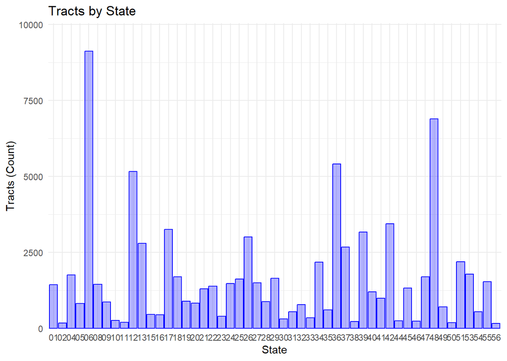

```r
tract_county_2022 %>%
  group_by(state) %>%
  count() %>%
  arrange(desc(n)) %>%
  ggplot(aes(x = factor(state), y = n)) +
  geom_col(color = "blue", fill = alpha("blue", 0.3)) +
   scale_y_continuous(expand = expansion(mult = c(0, 0.1))) +
  theme_minimal() +
  ggtitle("Tracts by State") +
  labs(x = "State",
       y = "Tracts (Count)")
```

## Sort

Sort the file so that it goes in order of state and county.

```r
tract_county_2022 <- tract_county_2022 %>%
  arrange(state, county)
```

## Write file

Save as “tract-county-crosswalk_2022.csv” in the data file folder.

```r
write_csv(tract_county_2022, here::here("geographic-crosswalks", "data", "tract-county-crosswalk_2022.csv"))
```